# Part II - Analysis of Ford's GoBike trip data

## by Esther Goneh

## Investigation Overview

In this analysis I examined the `201902-fordgobike-tripdata` (2019 ford gobike tripdata) to uncover the features in the dataset. First I explored the dataset features by performing univariate explorative data analysis. Further I performed biviriate and multivariate explorative data analysis to gain even more insight into the dataset.

The key insights gained from the dataset are: Subscribers use gobikes primarily to go and return from work, while customers are laisure users. Males and younger individuals are more like to share bikes. Individuals sharing bike use it for short trips. Females and young individuals are more likely to take longer trip durations.

## Dataset Overview

The dataset for this analysis consists of 183412 trip data of Ford Gobike users in the Sanfracisco area. Each trip is anonymize and contains data such as:

- Ride duration
- Ride start time
- Ride end time
- Start station id
- Start station name
- Start station latitude
- Start station longitude
- End station id
- End station name
- End station latitude
- End station longitude
- Bike id
- User type
- Member birth year
- Member gender
- Bike share for all trip

## The time with the highest number of trips

- The highest number of rides takes place at 8AM and 5PM. This is consistent with the time individuals leaves for and return from work.
- The highest number of rides starts on the Thursday, while the weekends (Saturday and Sunday) have the least number of rides.

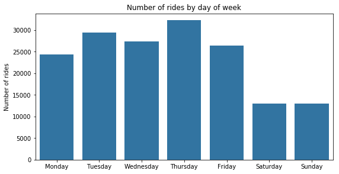

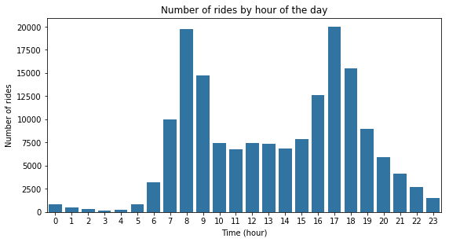

## Type of users

- 91.7% of the riders are subscribers, while customers consists of 8.3% of the riders.

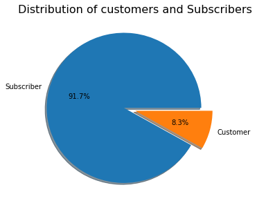

## Gender of riders

- Males makes up 75% of all the riders while females consists of 23.0% of the riders.

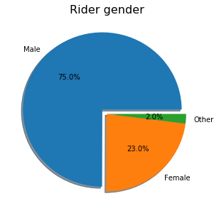

## Trip duration

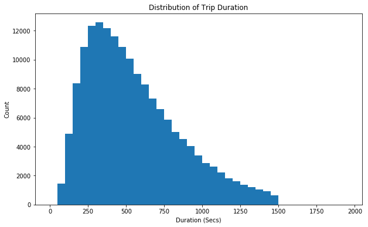

## Age and bike shared

- Younger people share rides more ofetn than older people.

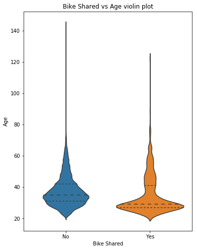

## Gender and trip duration

- The duration for trips by females is slightly longer than male trips.

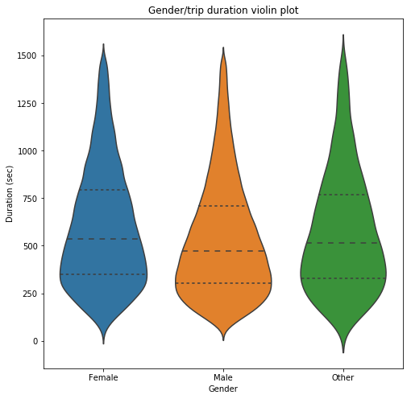

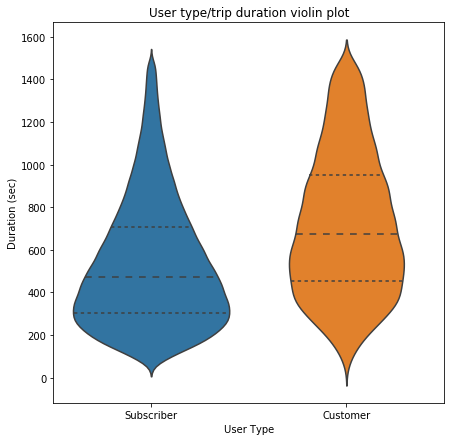

## User type, ride day of week and ride duration

- The duration of ride for subscribers is pretty much the same throught the week, the customers however take longer rides during the weekend.

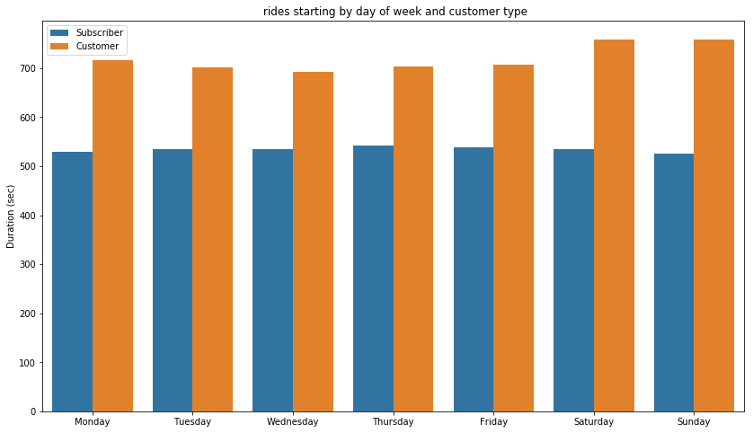

## Bike shared, Gender and duration

- Shared bike have the shorter trip duration across genders

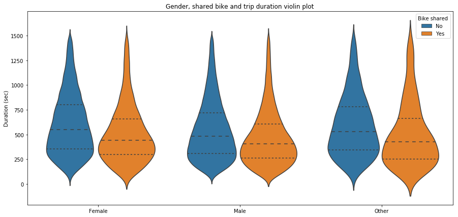